# Measures of Association

Analysing Data Week 5

Dr Jennifer Mankin

Click for slides

## Overview of the Next Weeks

- Today: Measures of Association
- Week 6: Comparing Two Means
- Week 7: Lab Report Writing
- Week 8: The Linear Model

## Overview of Today’s Topics

- Review of Important Ideas
  - Continuous vs Categorical Data
  - Distributions, test statistics, and NHST
- Tests of Association
  - What can we learn from these tests?
  - Continuous Data: Correlation coefficient *r*
  - Frequency Data: Chi-squared test *χ*<sup>2</sup>

## Review of Important Ideas

- Data can be measured in many ways
  - Continuous, categorial, ratio, ordinal…
- The type of data can have a big impact on your analysis and interpretion of results

## Continuous Data

- A matter of *degree*; answers the question “How much?”
  - Typically a score or measurement
  - Examples: a quiz marks, height in cm, response latency
  - If it makes sense to have a *mean*, you likely have continuous data

## Categorical Data

- A matter of *membership*; answers the question “Which one?”
  - Typically a group or label
  - Examples: practical group, alive vs. dead, control vs experimental condition
  - Membership in any category is binary (either in or out)

## Distributions, Test Statistics, and NHST

- Everything from the past few weeks we will now put into action!
- For each statistical analysis, we will have the same ingredients:
  - Data
  - A test statistic
  - The distribution of that test statistic
  - The probability *p* of the value of the test statistic we have under the null hypothesis H<sub>0</sub>

## Reminder about NHST

- For all of our tests, we assume that **the null hypothesis is true** unless we have evidence to suggest that this is unlikely
  - “Evidence” such as a test statistic that is sufficiently unlikely to occur under H<sub>0</sub>
  - In that case, we reject the null and accept the alternative hypothesis H<sub>1</sub>
- In psychology, “sufficiently unlikely” is typically defined as less than 5% probability (*p* < .05)
  - Nothing magical about this number!

## Overall Reminder

- As scientistis we want to believe true things about the world, and disbelieve false things
- NHST (*p*-values), and statistics more generally, are systems to help us make decisions about whether, and to what degree, we believe something is true

## Measures of Association

- Essential questions: are two variables related to each other, or unrelated (independent)? How can we quantify this relationship?
  - Choose a test statistic that best captures the relationship you want to model
- Today’s tests:
  - Correlation (*r*)
  - Chi-Squared (*χ*<sup>2</sup>)

## Correlation

- Quantifies the **degree** and **direction** of a numeric relationship
- Typically used with two (or more) continuous variables
  - Can be used when one is categorical!
- Today’s example: Gender and Sexuality data from the questionnaire

## Correlation: Visualisation

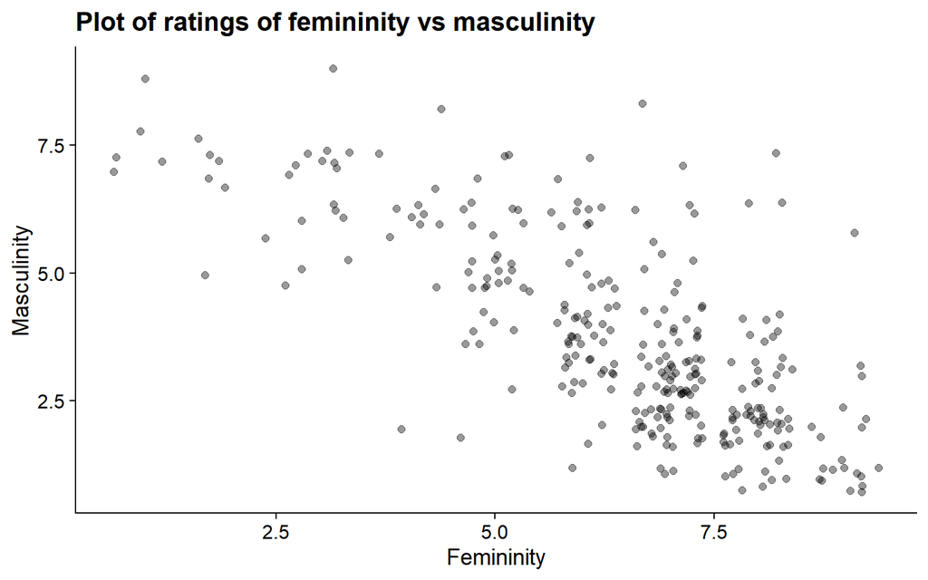

- The plot shows that people who gave high ratings for femininity tended to give low ratings for masculinity, and vice versa
- Things we might like to know:
  - How strong is this relationship?
  - Should we believe that it’s real (ie representative of people/first-year psychology students in general?)

## Correlation: How strong?

- We can quantify the **strength** and **direction** of the relationship between femininity and masculinity with Pearson’s correlation coefficient *r*
- Strength: absolute value of *r* between 0 and 1
  - 0: no relationship at all
  - 1: perfect relationship
- Direction: whether the value of *r* is positive or negative
  - Positive: as one variable increases, the other tends to increase
  - Negative: as one variable increases, the other tends to decrease
- So, values range from -1 (perfect negative) through 0 (no relationship) to 1 (perfect positive)

## Correlation: Let’s Try It!

```r
gensex %>%
  select(Gender_fem_1, Gender_masc_1) %>%
  cor(method = "pearson")
              Gender_fem_1 Gender_masc_1
Gender_fem_1     1.0000000    -0.7553645
Gender_masc_1   -0.7553645     1.0000000
```

- So, our correlation coefficient *r* is -0.76
  - The negative sign (-) means as femininity increases, masculinity tends to decrease (and vice versa)
  - We saw this on the plot as a downward trend left to right
  - The absolute value of 0.76 is **very** strong - quite close to 1!

## Correlation: Is It Real?

- We now have our data and our test statistic *r* (-0.76)
- We can now ask likely we are to get a value of -0.76 if in fact femininity and masculinity have a true *r* of 0
  - i.e. the null hypothesis is in fact true
  - We will use the standard significance level of < .05 in this case

```r
fm.r <- cor.test(gensex$Gender_fem_1, gensex$Gender_masc_1, alternative = "two.sided", method = "pearson")
fm.r

    Pearson's product-moment correlation

data:  gensex$Gender_fem_1 and gensex$Gender_masc_1
t = -20.098, df = 304, p-value < 2.2e-16
alternative hypothesis: true correlation is not equal to 0
95 percent confidence interval:
 -0.7997536 -0.7027607
sample estimates:
       cor
-0.7553645
```

We can report this as: “There was a significant correlation between femininity and masculinity, *r*(304) = -0.76, *p* < .001.”

## Correlation: *r* or *t*?

Our output includes *t* and its associated *p*-value:

```
    Pearson's product-moment correlation

data:  gensex$Gender_fem_1 and gensex$Gender_masc_1
t = -20.098, df = 304, p-value < 2.2e-16
alternative hypothesis: true correlation is not equal to 0
95 percent confidence interval:
 -0.7997536 -0.7027607
sample estimates:
       cor
-0.7553645
```

This is because the probability *p* associated with *r* actually comes from a *t*-distribution with N - 2 degrees of freedom!

## Correlation: So Far

- We have seen that the correlation coefficient *r* expresses the strength and direction of the relationship between two variables
- We can use this to **compare** the strength of different relationships

## Correlation: Comparing *r*s

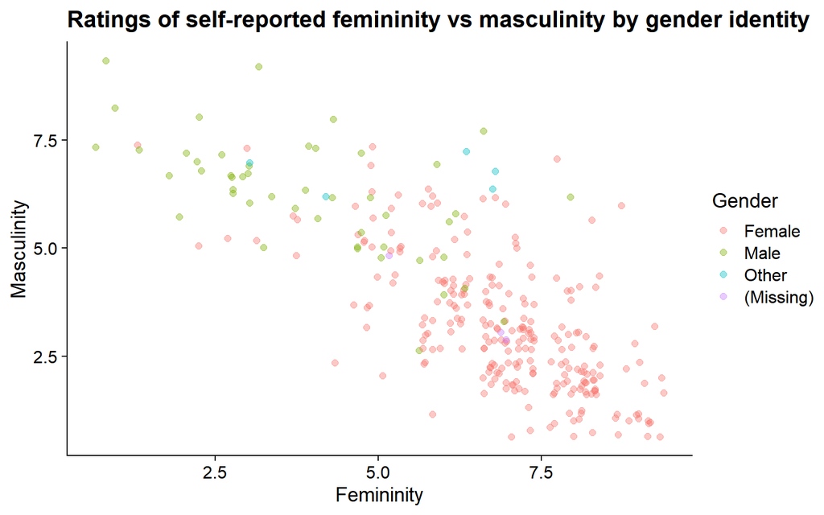

## Correlation: Interpretation

- For both female-ID and male-ID people, there is a fairly strong negative relationship
- We can use *r* to quantify whether this relationship is stronger for female-ID or male-ID people
  - Simply compare the values of *r* for females and males separately

## Correlation: Comparing values

- For female-ID people, *r*(248) = -0.64, *p* < .001
- For male-ID people, *r*(46) = -0.58, *p* < .001
- So, the relationship between femininity and masculinity is stronger for female-ID people
- WARNING: we should be careful about this, because we had 250 female-ID participants and 48 male-ID participants!
  - How can we check the accuracy of our estimates of *r* for each gender ID?
- For female-ID people, *r* was -0.64, 95% CIs [-0.7, -0.56] so +/- 0.07
- For male-ID people, *r* was -0.58, 95% CIs [-0.74, -0.36] so +/- 0.16
- Having more female-ID people means our CIs are smaller and estimates are more accurate
  - As these CIs overlap substantially, it’s possible that the true value of *r* for male-ID people is not actually different from female-ID people

## Correlation: **VOCAB ALERT!**

- In common language, “correlated” means “related to in some way, usually causally”
  - Statistics: the (standardised) degree to which two or more variables covary, ie change in relation to each other
- “Correlation” is a technical term!
  - In your reports, do not say two things are “correlated” unless you plan to report *r* as evidence!
  - Instead: variables have a relationship/are related to each other

## Correlation: Summary

- The correlation statistic *r* helps us quantify and compare the strength and direction of relationships between variables
  - How *r* is calculated, relationship to *t*, etc: see reading!
- Correlation **DOES NOT IMPLY CAUSATION!!!!!!!**
- More practice with interpreting *r* with [this fun little game](http://guessthecorrelation.com/)

## Making Progress

- Correlations: sorted!
  - But we’ll come back to them later…
- Next up: Chi-Square (*χ*<sup>2</sup>)

## Chi-Square Test *χ*<sup>2</sup>

- Quantifies the relationship between frequencies
- Typically used with two (or more) categorical variables
  - Shows up in **many** contexts!
  - Also used for comparing different models…more in second year!
- Today’s example: Simulated data based on the green study, Griskevicius et al. (2010)

## Green Study: Design

- Research question: Why do people choose to buy “green” products?
  - Conceptual hypothesis: buying “green” products is related to status motives
- Griskevicius et al. (2010) operationalisation:
  - Story condition: read high-status story or status-neutral story
  - Product choice: green or more luxurious non-green product
    - Three products: car, soap, and dishwasher
  - Operational hypothesis: people in the **high-status** condition will choose the **green** products more often than people in the control condition

## Green Study: Data

Here’s what the data may look like

- CONDITION: control story or experimental (high-status) story
- CHOICE: product choice, either green or luxury
- We’ll just look at the results for one of the three products - the car

```
# A tibble: 443 x 6
   ID_CODE GENDER   AGE CONDITION PRODUCT    CHOICE
   <fct>   <fct>  <dbl> <fct>     <fct>      <fct>
 1 WYYJ    male      25 control   dishwasher luxury
 2 WYYJ    male      25 control   cleaner    green
 3 WYYJ    male      25 control   car        luxury
 4 TBSY    female    19 control   dishwasher green
 5 TBSY    female    19 control   cleaner    luxury
 6 TBSY    female    19 control   car        green
 7 CVWL    female    18 control   dishwasher green
 8 CVWL    female    18 control   cleaner    green
 9 CVWL    female    18 control   car        luxury
10 ILVB    other     21 control   dishwasher green
# ... with 433 more rows
```

## Green Study: Summary Table

Observed Frequencies of Car Product Choices by Story Type

|  | Non-Green Luxury Product | Green Product |
| --- | --- | --- |
| Control Story | 51 | 26 |
| High-Status Story | 33 | 37 |

## Green Study: Graph

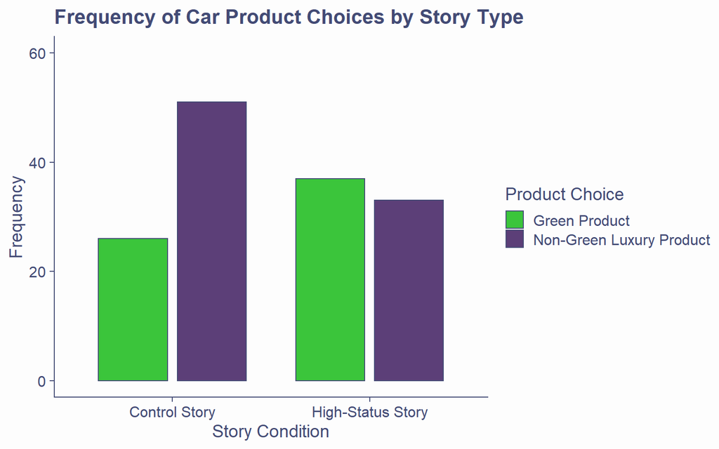

## Green Study: Analysis

- Are story condition and product choice **independent** of each other?
  - If yes: story condition has no association with product choice
  - If no: story condition is associated with product choice
- The observed frequencies for our sample show some pattern
- How much of a pattern is enough to believe that condition and choice are **not** independent?
  - Compare to what we might expect under the null hypothesis
  - Calculate *χ*<sup>2</sup> to quantify this

## Chi-Squared: Expected Frequencies

Expected Frequencies of Product Choices by Story Condition

|  | Non-Green Luxury Product | Green Product |
| --- | --- | --- |
| Control Story | 44 | 33 |
| High-Status Story | 40 | 30 |

- We might expect that there are equal counts in each cell (combination of conditions)
- BUT: To account for unequal numbers of people who chose the green vs non-green products, instead we can calculate the **expected frequencies**
  - That is: how many counts we would expect in each cell, if the null hypothesis is true
  - See An Adventure in Statistics (pgs 434 to 442) for calculations

## Note on Chi-Squared: Expected Frequencies

- Important assumption: you can only use *χ*<sup>2</sup> if you have expected frequencies greater than 5 in each cell
  - Smaller than this and the test lacks sufficient **power** to detect relationships
- For very small expected frequencies, you may want to use Fisher’s Exact Test instead
  - For more on this, see An Adventure in Statistics pgs 442 - 444

## Chi-Squared Test: Observed vs Expected

- Next, we compare the expected frequencies to our observed frequencies
- The *χ*<sup>2</sup> test statistic represents the (standardised) difference between the observed and expected frequencies
  - The bigger *χ*<sup>2</sup> is, the bigger the difference is between our data and what we expect under the null hypothesis

## Chi-Squared: Output

```
    Pearson's Chi-squared test with Yates'
    continuity correction

data:  green_sum
X-squared = 4.7051, df = 1, p-value = 0.03007
```

- The calculated value for *χ*<sup>2</sup> (here, “X-squared”) is 4.71
- The degrees of freedom, which determines the *χ*<sup>2</sup> distribution, is 1 from which we get…
- The *p*-value, which represents the probability of getting a test statistic this big if the null hypothesis is in fact true
  - Here, *p* is very small ( = .030), so pretty unlikely!
  - We might conclude that the null hypothesis **might not be true**

## IMPORTANT!!!

- We can only test the significance (probability) of the null hypothesis being true
  - This **does not mean we have evidence for the alternative hypothesis**
- In other words: Our test tells us that it is unlikely that there is no relationship (small *p*-value under the null hypothesis)
  - From that we **infer** that maybe there is a relationship
  - That will only be a sensible thing to infer if we have carefully controlled for all other explanations

## Green Study: What Can We Conclude?

- We wanted to know whether status motives influence “green” purchases
- Operationalised as whether reading a high-status vs control story was associated with the frequency of green product vs a non-green luxury product choice
- We found that 52.86% of participants who read the high-status story chose a green car over a more luxurious non-green alternative,while only 33.77% of participants who read the control story made the same choice (χ<sup>2</sup>(1) = 4.71, *p* = .030).
- So, our results suggest that high-status motives are related to how frequently people choose green products

## Lab Reports

- You can choose either the red or green study to write your report on
  - See [Lab Report Information on Canvas](https://canvas.sussex.ac.uk/courses/9242/pages/Lab%20Report%20Information%20and%20Resources?titleize=0) for more
- If you choose the green study (Griskevicius et al., 2010), you should use and report the results of *χ*<sup>2</sup>
  - Refer to the original paper for some ideas!

## Analysis for Lab Reports

- Inspect and clean the data
- Produce descriptives of participants (age, gender)
- Report observed frequencies and *χ*<sup>2</sup> results for all three product choices
  - Include at least one figure of the results
  - Will be covered in depth in the next tutorial and practical!

## Questions?

**Don’t forget to save this page on your computer, otherwise you will lose all notes!**